# PATH Report

Auto‑generated summary of PATH outputs with interactive maps

> PATH is a decision-support tool that provides users with information about where to prioritize post-fire hillslope-level treatment that minimizes cost, subject to biophysical constraints. It integrates WEPPcloud’s Omni Scenario Runner simulation outputs, which allows the assessment of multiple pre and post treatment scenarios. Users enter their treatment costs, landscape constraints, and biophysical thresholds and PATH identifies hillslopes for treatment using binary integer programming. This report provides a summary of PATH’s outputs including tables, plots, and maps of the selected hillslopes and treatments.

**Static PDF Version:** PATH_CE_Report_PDF.pdf

## 1. Parameters

The following Parameters were used for this PATH run:

```
Detected landscape: pacificcreek
Report schema: individual hillslopes (wepp-based)
```

| Hillslope Sediment Yield Threshold (tons/acre) | 10.00 |
| --- | --- |
| Outlet Sediment Discharge Threshold (tons) | 35000.00 |
| Slope filter | None |
| Burn Severity filter | None |
| Treatments | [mulch 0.5 tons/acre, mulch 1 tons/acre, mulch 2 tons/acre] |
| Treatment cost ($) | [1237.50, 2475.00, 4950.00] |
| Hillslope Data file | PATH_prepared_hillslope_data.csv |
| Subcatchment Spatial Layer | pacificcreek_subcatchments.WGS.JSON |
| Channels Spatial Layer | pacificcreek_channels.WGS.JSON |

## 2. Run Results

```
Threshold sweep ranges: Sddc=(32008, 44007), Sdyd=(0, 30)
```

### 2.1 Interactive Map of Selected Hillslopes

The map below displays the selected hillslopes by treatment. Hillslopes outlined in red exceeded the hillslope sediment yield (Sdyd) threshold even after treatment. Hover over hillslopes to see details.

[interactive chart not shown]

### 2.2 Key Outputs

|  | metric | value |
| --- | --- | --- |
| 0 | Total cost ($) | 3285338.76 |
| 1 | Total outlet sediment discharge reduction (tons) | 9007.10 |
| 2 | Final outlet sediment discharge (tons) | 34999.60 |

### 2.3 Hillslope Treatment and Final Sediment Yield

The following table shows the treatment assignment and final hillslope sediment yield. Hillslopes with final sediment yield above the threshold are highlighted in red. You can also download the full table as a CSV for further analysis.

| WEPP ID | Final Sediment Yield | Treatment |
| --- | --- | --- |
| 1 | 9.89 | 2 tons/acre |
| 2 | 9.55 | 1 tons/acre |
| 3 | 8.81 | No treatment |
| 4 | 5.03 | 2 tons/acre |
| 5 | 3.33 | 2 tons/acre |
| 6 | 0.09 | 2 tons/acre |
| 7 | 9.19 | 0.5 tons/acre |
| 8 | 0.83 | 1 tons/acre |
| 9 | 2.78 | 2 tons/acre |
| 10 | 17.52 | 2 tons/acre |
| 11 | 11.73 | 2 tons/acre |
| 12 | 4.71 | 2 tons/acre |
| 13 | 6.89 | No treatment |
| 14 | 20.05 | 2 tons/acre |
| 15 | 4.35 | 2 tons/acre |
| 16 | 0.75 | 2 tons/acre |
| 17 | 9.60 | 1 tons/acre |
| 18 | 16.21 | 2 tons/acre |
| 19 | 5.27 | 2 tons/acre |
| 20 | 6.24 | 1 tons/acre |
| 21 | 7.18 | 1 tons/acre |
| 22 | 8.47 | No treatment |
| 23 | 1.56 | 1 tons/acre |
| 24 | 5.49 | 1 tons/acre |
| 25 | 12.68 | 2 tons/acre |
| 26 | 11.33 | 2 tons/acre |
| 27 | 9.77 | 1 tons/acre |
| 28 | 11.56 | 2 tons/acre |
| 29 | 10.44 | 2 tons/acre |
| 30 | 0.87 | 1 tons/acre |

[output cut: 70 more lines]

- PATH_hillslope_treatment_summary.csv — Hillslope Group/WEPP ID, Final Sediment Yield, and Treatment assignment
- PATH_sdyd_threshold_exceeded.csv — Hillslopes where Sediment Yield threshold was not met after treatment

## 3. Sediment Threshold Analysis

This section provides additional analysis of the Hillslope Sediment Yield and Outlet Sediment Discharge thresholds and their impact on treatment selection and costs.

```
Threshold analysis ready: 1596 rows
```

### 3.2 Cost vs. Threshold Visualizations

The following response curves show how total treatment cost changes when one threshold is varied while the other is held fixed at the user-selected value. Together they help distinguish which threshold is most strongly constraining the optimization and where additional tightening of thresholds produces disproportionately large cost increases.

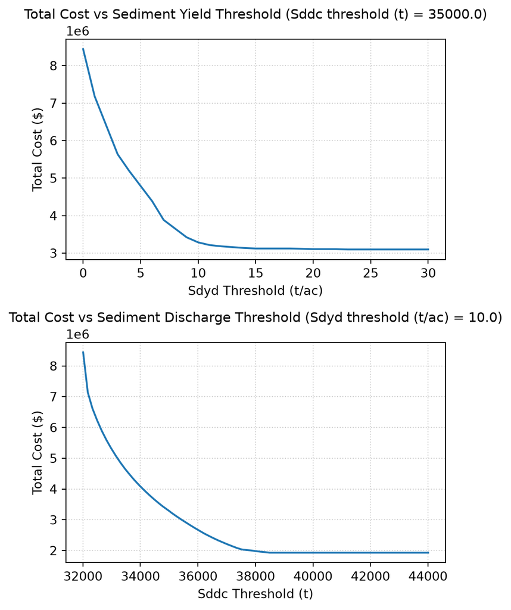

The 3D surface plot below shows how total cost varies across the full range of threshold combinations. The point highlighted in red corresponds to the user-selected thresholds. This visualization can help identify whether the optimization is more sensitive to one threshold versus the other, and whether there are any non-linear interactions between the thresholds that lead to disproportionate cost increases in certain regions of the parameter space.

[interactive chart not shown]